# boxPlot.md

# Prepare the data

```r
# Convert the variable dose from a numeric to a factor variable
ToothGrowth$dose <- as.factor(ToothGrowth$dose)
head(ToothGrowth)
```

```
##    len supp dose
## 1  4.2   VC  0.5
## 2 11.5   VC  0.5
## 3  7.3   VC  0.5
## 4  5.8   VC  0.5
## 5  6.4   VC  0.5
## 6 10.0   VC  0.5
```

# Basic box plots

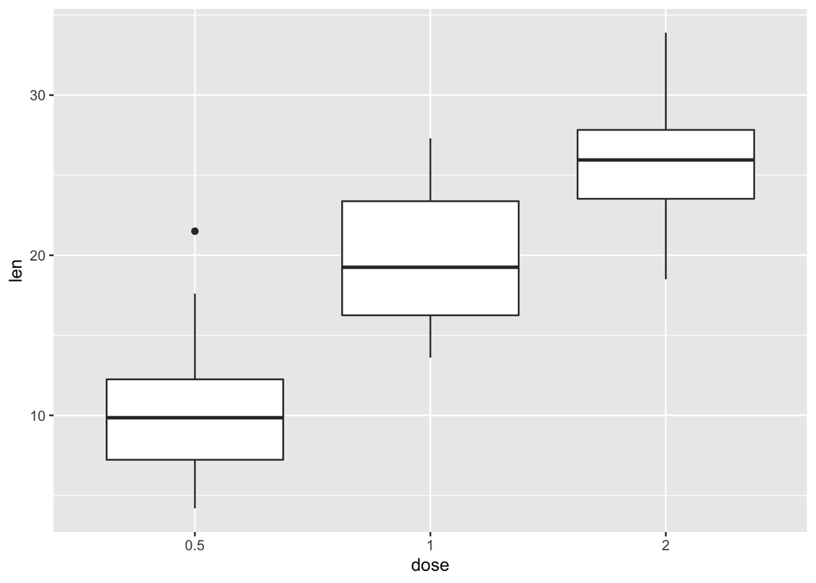

```r
library(ggplot2)
# Basic box plot
p <- ggplot(ToothGrowth, aes(x=dose, y=len)) +
  geom_boxplot()
p
```

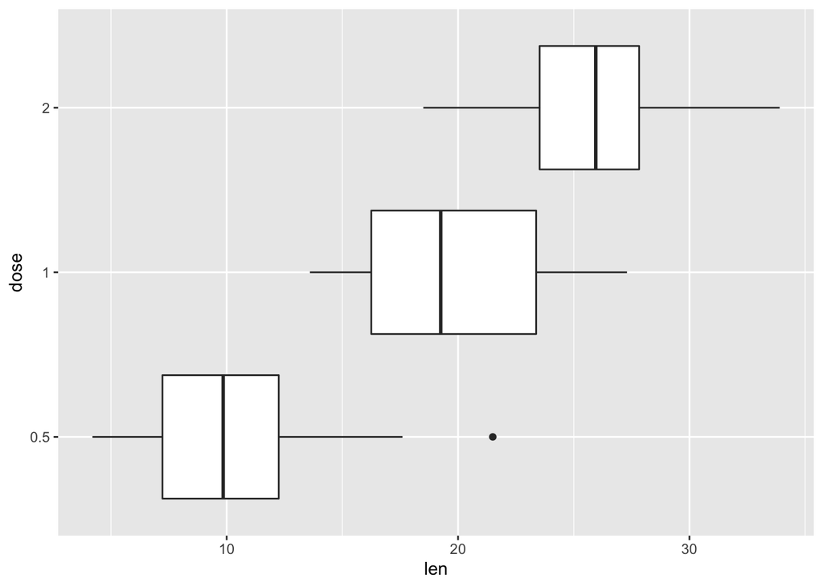

```r
# Rotate the box plot
p + coord_flip()
```

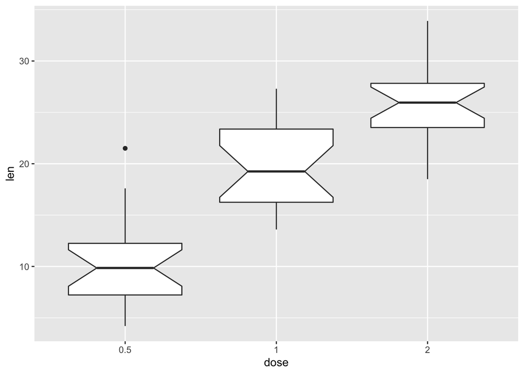

```r
# Notched box plot
ggplot(ToothGrowth, aes(x=dose, y=len)) +
  geom_boxplot(notch=TRUE)
```

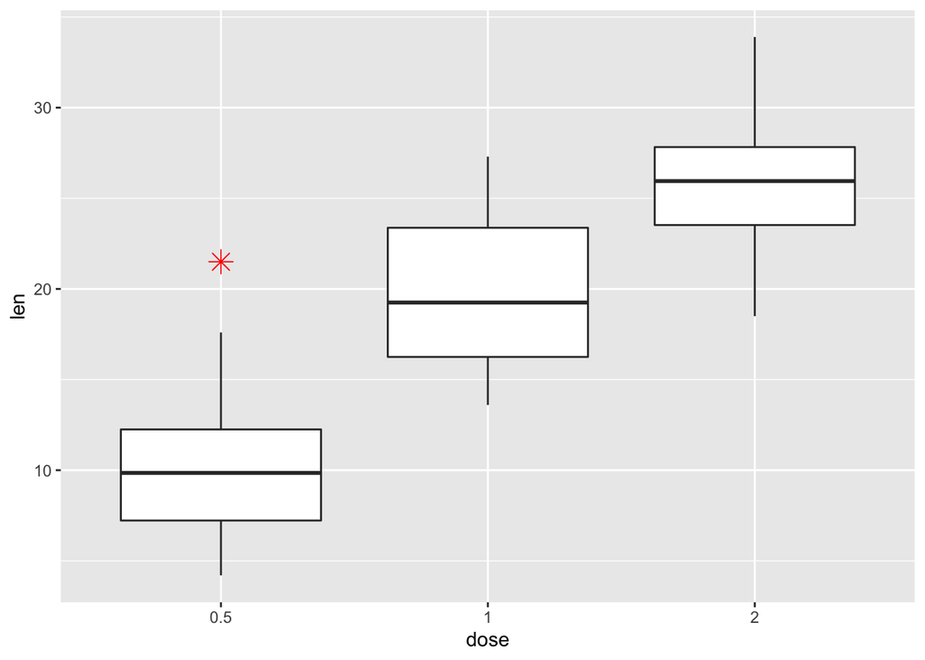

```r
# Change outlier, color, shape and size
ggplot(ToothGrowth, aes(x=dose, y=len)) +
  geom_boxplot(outlier.colour="red", outlier.shape=8,
                outlier.size=4)
```

The function **stat_summary()** can be used to add mean points to a box plot :

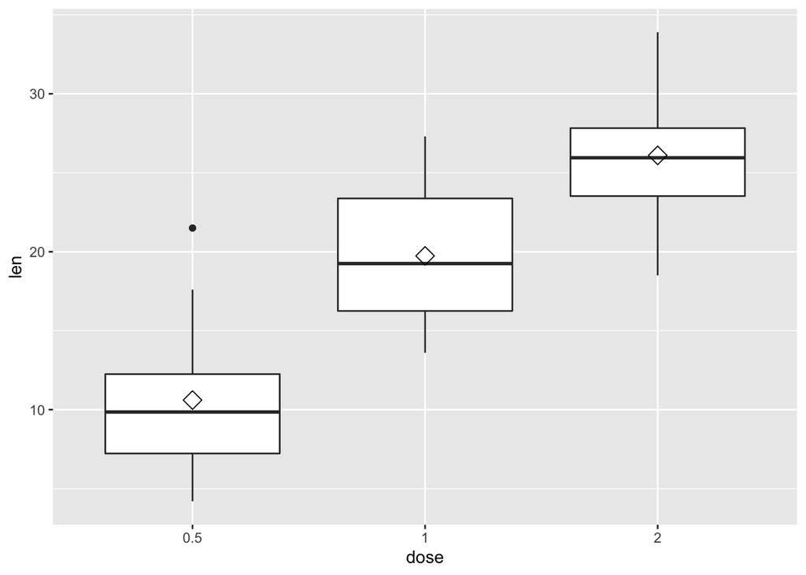

```r
# Box plot with mean points
p + stat_summary(fun=mean, geom="point", shape=23, size=4)
```

Choose which items to display :

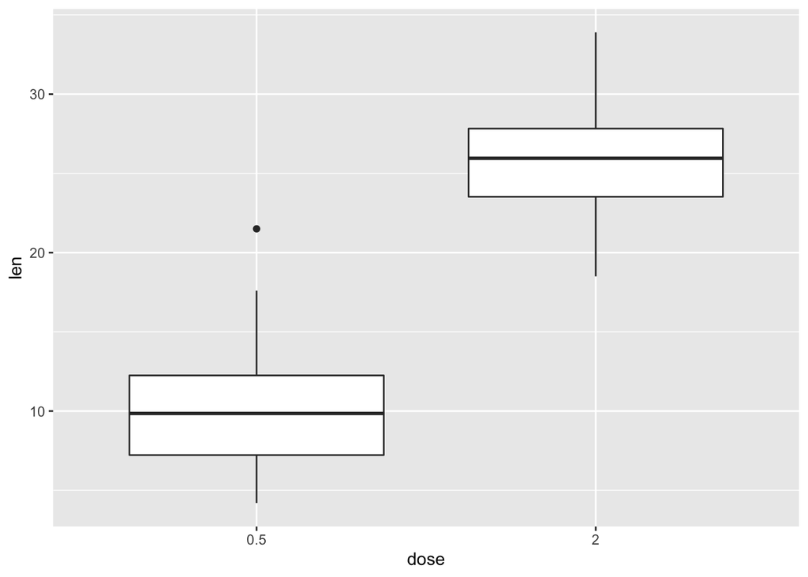

```r
p + scale_x_discrete(limits=c("0.5", "2"))
```

# Box plot with dots

Dots (or points) can be added to a box plot using the functions **geom_dotplot()** or **geom_jitter()** :

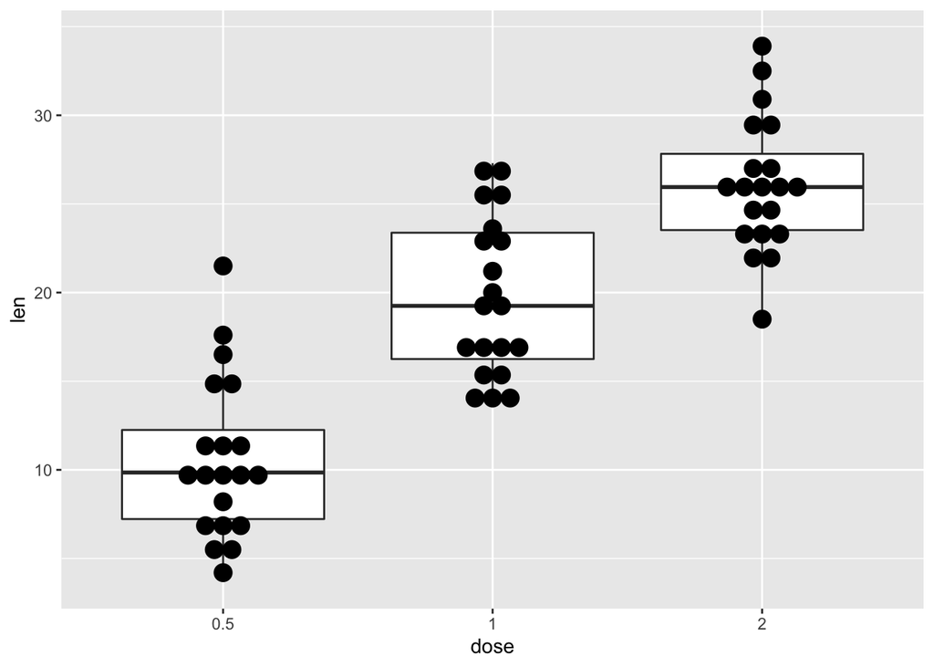

```r
# Box plot with dot plot
p + geom_dotplot(binaxis='y', stackdir='center', dotsize=1)
```

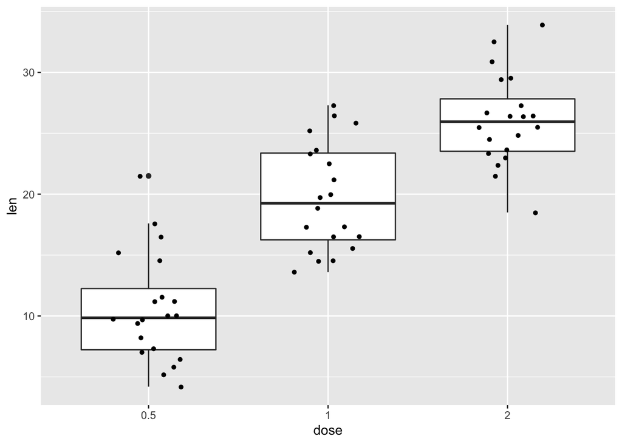

```r
# Box plot with jittered points
# 0.2 : degree of jitter in x direction
p + geom_jitter(shape=16, position=position_jitter(0.2))
```

# Change box plot colors by groups

## Change box plot line colors

Box plot line colors can be automatically controlled by the levels of the variable *dose() :

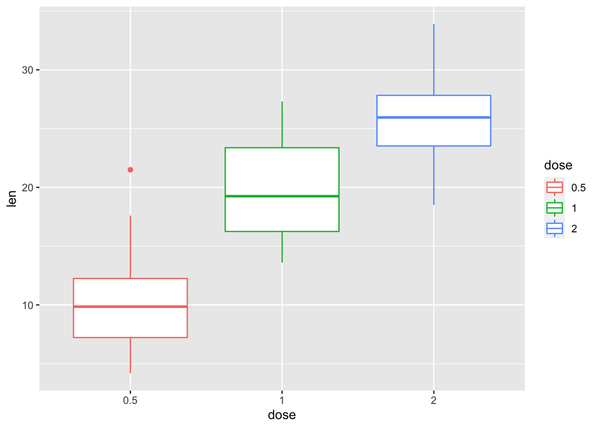

```r
# Change box plot line colors by groups
p<-ggplot(ToothGrowth, aes(x=dose, y=len, color=dose)) +
  geom_boxplot()
p
```

It is also possible to *change manually box plot line colors* using the functions :

- **scale_color_manual()** : to use custom colors
- **scale_color_brewer()** : to use color palettes from **RColorBrewer** package
- **scale_color_grey()** : to use grey color palettes

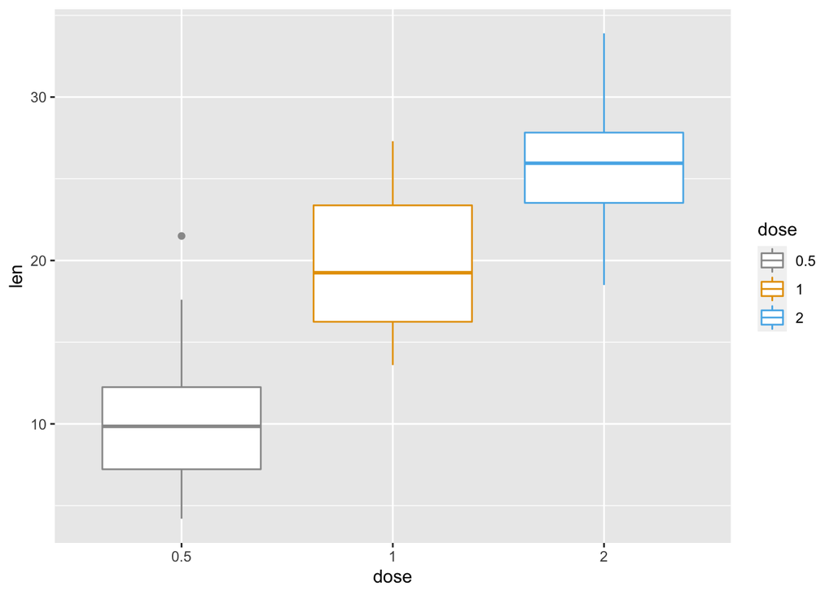

```r
# Use custom color palettes
p+scale_color_manual(values=c("#999999", "#E69F00", "#56B4E9"))
```

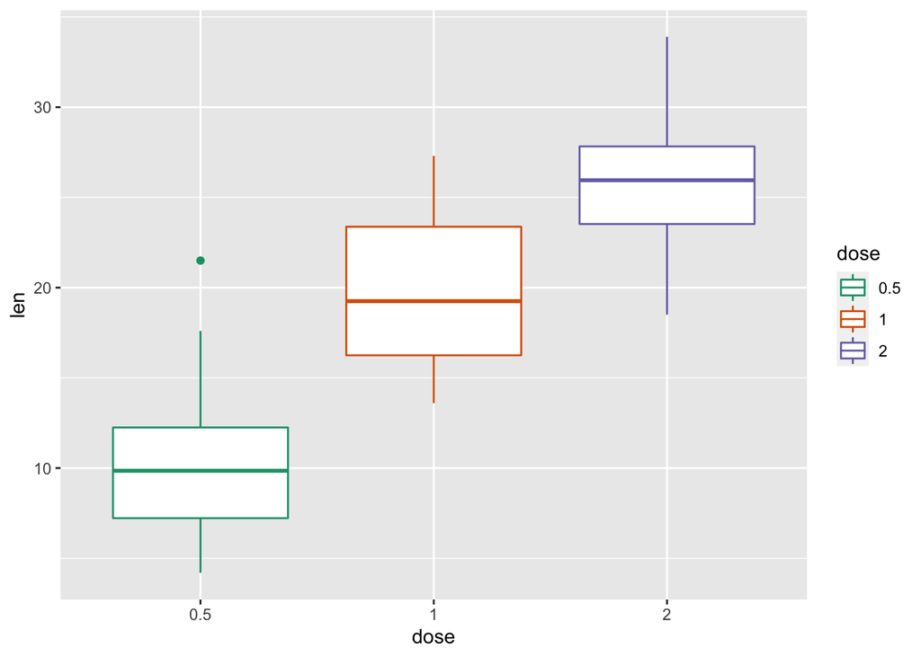

```r
# Use brewer color palettes
p+scale_color_brewer(palette="Dark2")
```

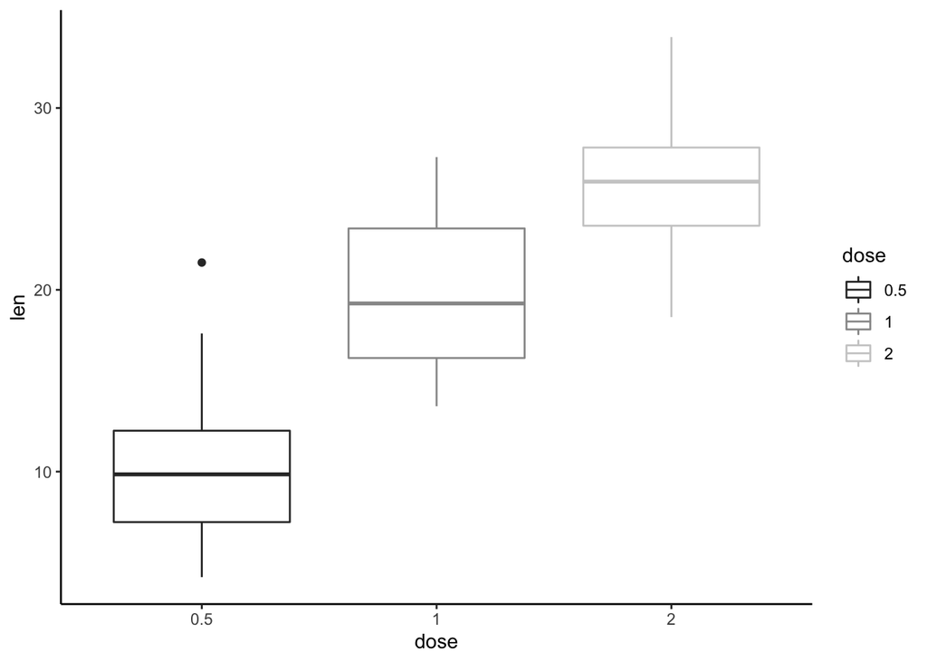

```r
# Use grey scale
p + scale_color_grey() + theme_classic()
```

Read more on ggplot2 colors here : [ggplot2 colors](http://www.sthda.com/english/wiki/ggplot2-colors-how-to-change-colors-automatically-and-manually)

## Change box plot fill colors

In the R code below, box plot fill colors are automatically controlled by the levels of *dose* :

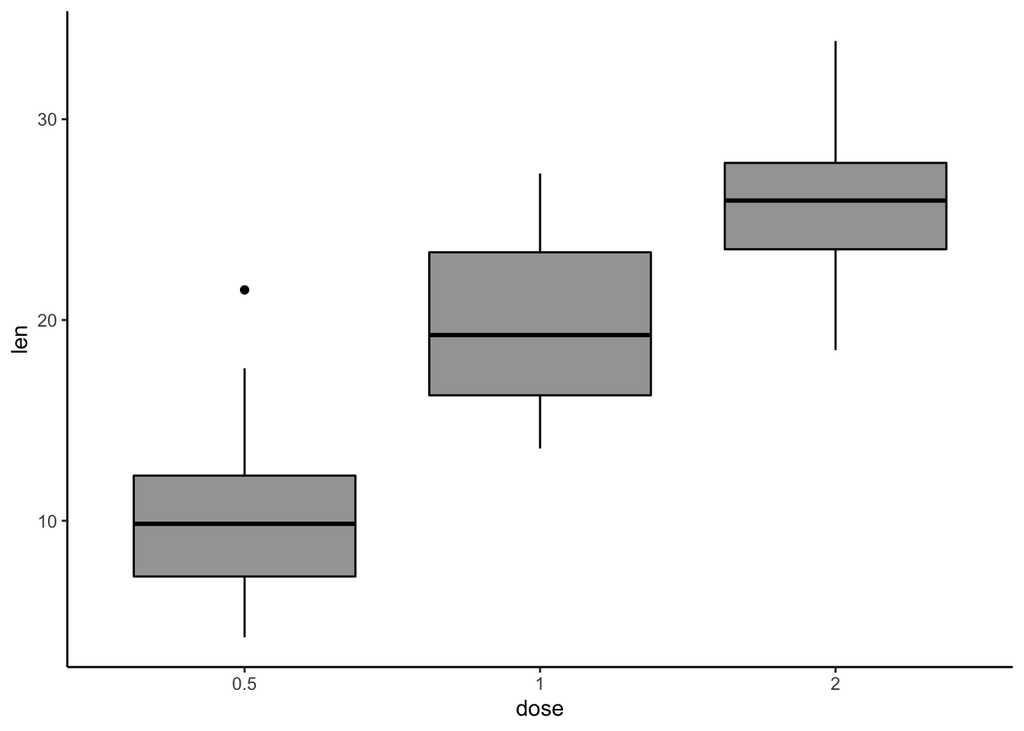

```r
# Use single color
ggplot(ToothGrowth, aes(x=dose, y=len)) +
  geom_boxplot(fill='#A4A4A4', color="black")+
  theme_classic()
```

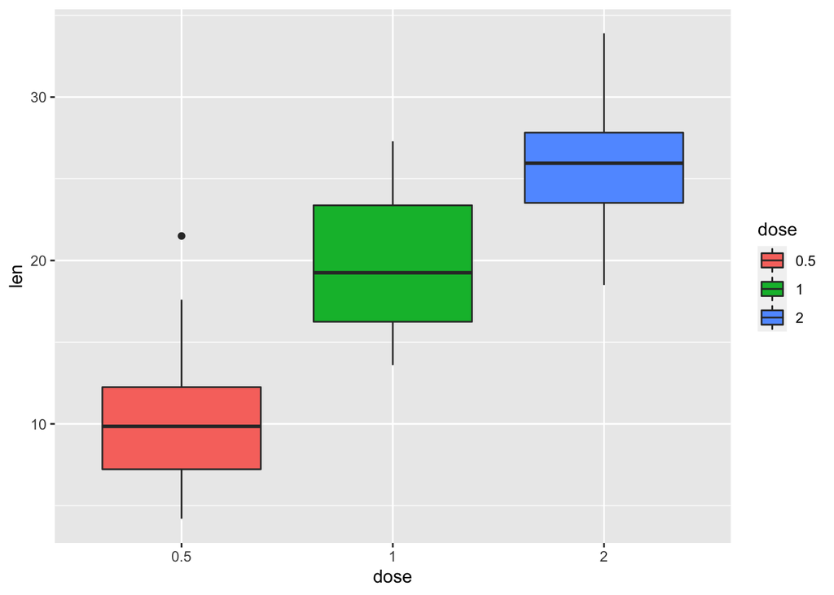

```r
# Change box plot colors by groups
p<-ggplot(ToothGrowth, aes(x=dose, y=len, fill=dose)) +
  geom_boxplot()
p
```

It is also possible to change manually box plot fill colors using the functions :

- *scale_fill_manual()* : to use custom colors
- *scale_fill_brewer()* : to use color palettes from *RColorBrewer* package
- *scale_fill_grey()* : to use grey color palettes

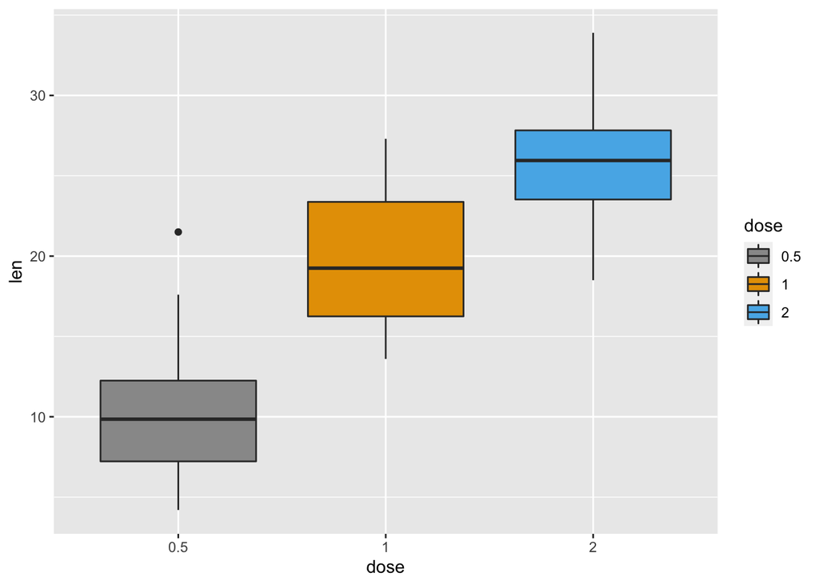

```r
# Use custom color palettes
p+scale_fill_manual(values=c("#999999", "#E69F00", "#56B4E9"))
```

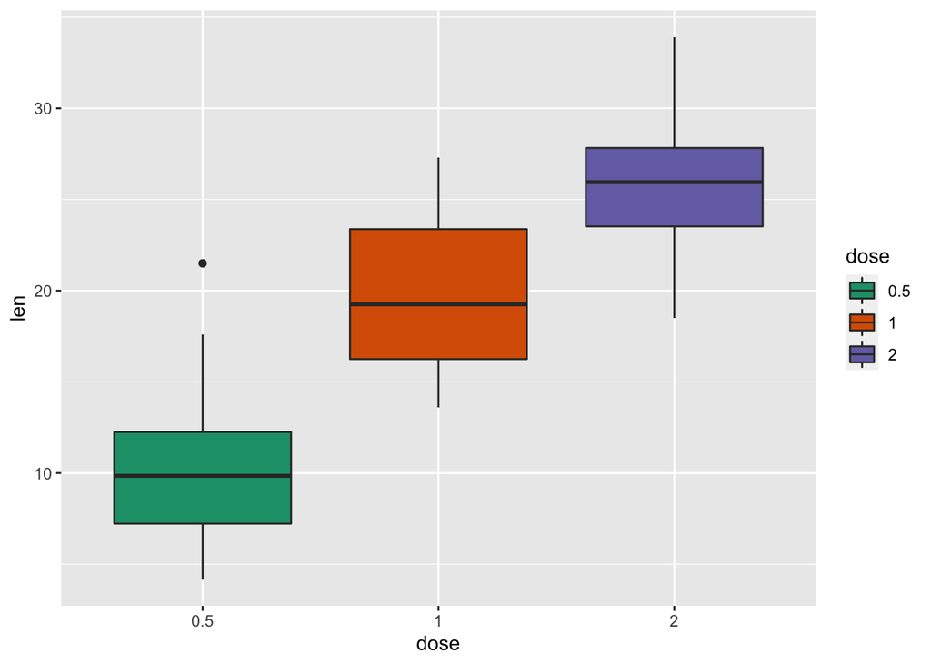

```r
# use brewer color palettes
p+scale_fill_brewer(palette="Dark2")
```

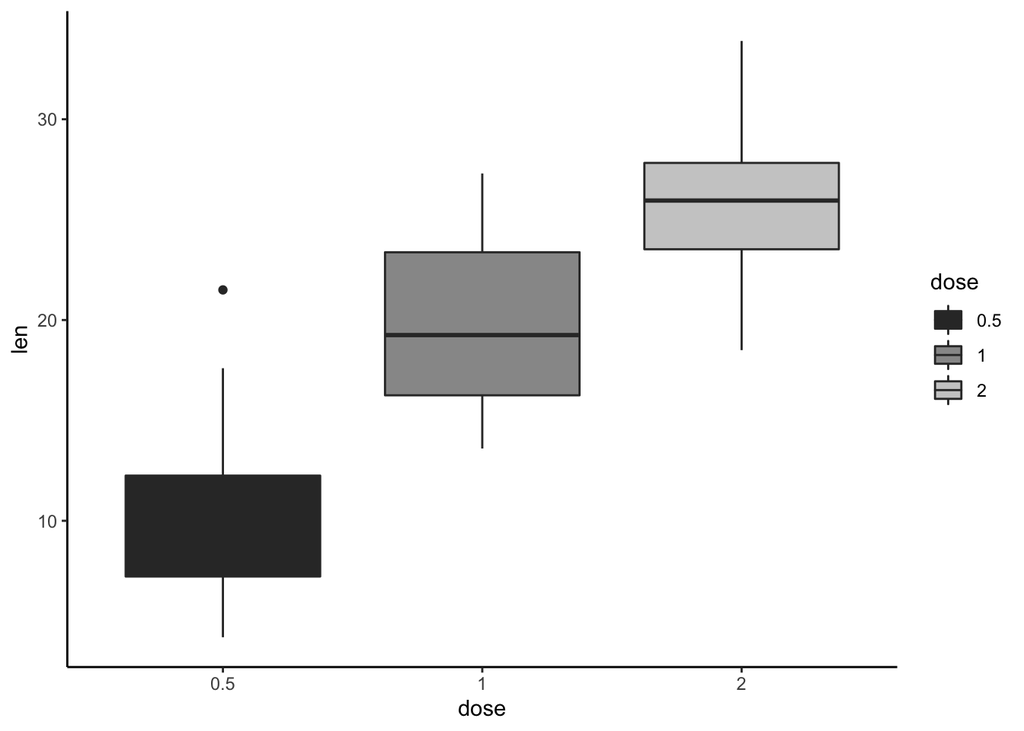

```r
# Use grey scale
p + scale_fill_grey() + theme_classic()
```

Read more on ggplot2 colors here : [ggplot2 colors](http://www.sthda.com/english/wiki/ggplot2-colors-how-to-change-colors-automatically-and-manually)

# Change the legend position

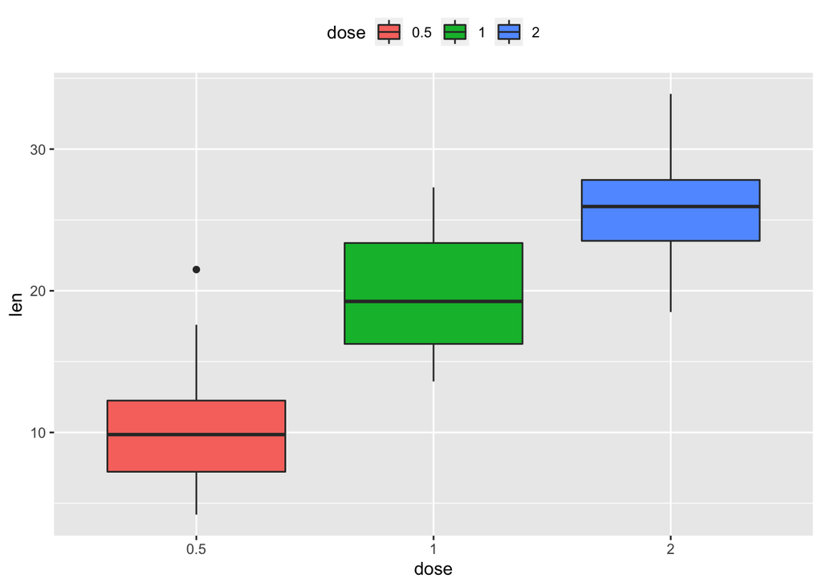

```r
p + theme(legend.position="top")
```

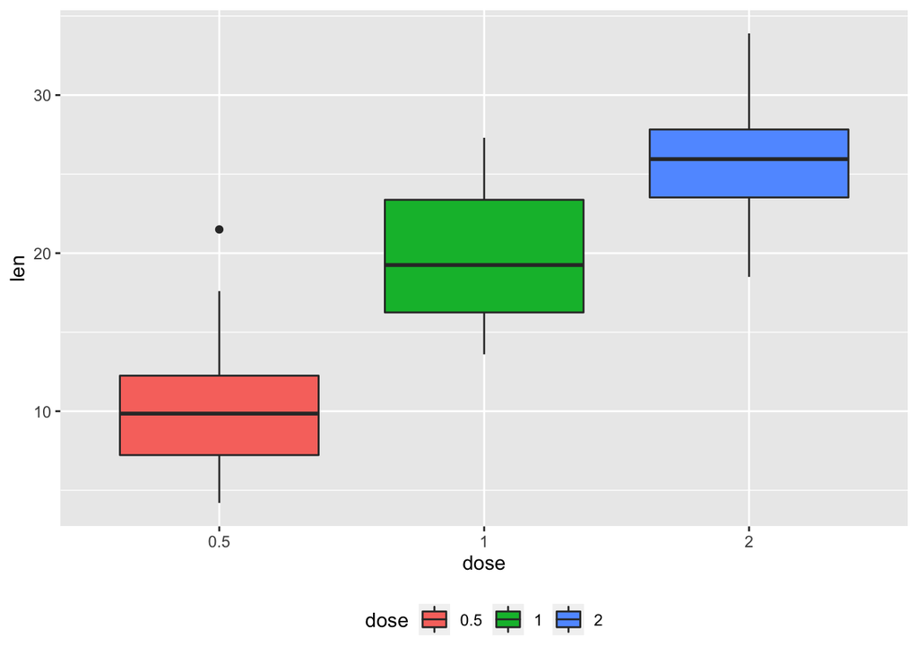

```r
p + theme(legend.position="bottom")
```

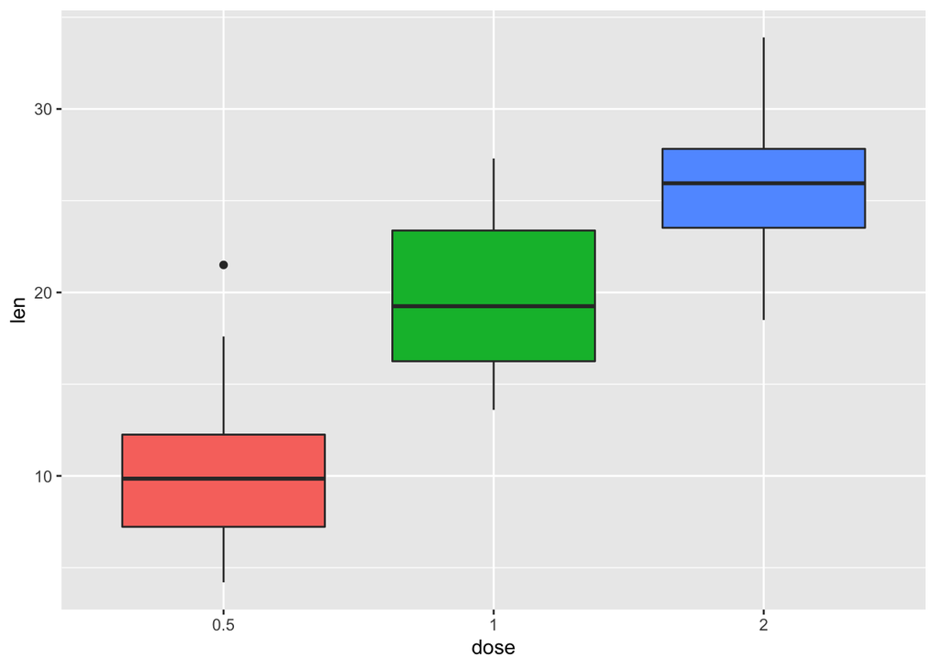

```r
p + theme(legend.position="none") # Remove legend
```

The allowed values for the arguments **legend.position** are : “left”,“top”, “right”, “bottom”.

Read more on ggplot legend : [ggplot2 legend](http://www.sthda.com/english/wiki/ggplot2-legend-easy-steps-to-change-the-position-and-the-appearance-of-a-graph-legend-in-r-software)